# Real Estate Price Prediction with Machine Learning

Session 4

Associate Professor Ole Maneesoonthorn

Predictive Analytics, Term 4 2020

## Melbourne Real Estate Data

Can we predict the “sold” prices of the real estate property? This data set collates the property prices sold in a certain Melbourne suburb. A portion (not all) of this suburb is part of a well regarded public secondary school zone that is known to generate premium on the sales price.

Our goal is to make use of the predictive analytics toolset to contruct predictions of the real estate sale prices.

**Data description:**

1. Price - sold price of the property, recorded in thousands of Australian dollars
2. Beds - number of bedrooms advertised
3. Baths - number of bathrooms advertised
4. Cars - number of carpark spaces advertised
5. Area - advertised land size in squared metre
6. SchoolZone - Yes/No variable indicating whether the property is located in a sought after school catchment zone
7. Auction - Yes/No variable indicating whether the property was sold through auction
8. New - Yes/No variable indicating whether the property has been built in the past 10 years
9. Subdivided - Yes/No variable indicating whether the property has been subdivided

We will continue our modelling from the workspace saved from Session 3, so that we can compare our new predictive results to the previous models, and use any existing functions that have already been defined.

```r
#Load saved workspace from Session 3
load('REPriceSession3.RData')
```

In this session, we will explore three ensemble methods: bagging, random forest and boosting; and the support vector machine regression.

### Bagging

Bagging is a machine learning method that relies on the process of “bootstrapping” - that is, resampling the data with replacement. We will be using the “caret” library to train a bag of trees for the real estate prices. A random seed was set to make sure the results remain static when you re-run the algorithm.

```r
# Load caret & vip library
library(caret)
library(vip)

# Bagging for regression tree
set.seed(1234)
# Training the bagging algorithm
bag <- train(Price~., data = trainData, method='treebag')
print(bag)
```

```
## Bagged CART
##
## 263 samples
##   8 predictor
##
## No pre-processing
## Resampling: Bootstrapped (25 reps)
## Summary of sample sizes: 263, 263, 263, 263, 263, 263, ...
## Resampling results:
##
##   RMSE      Rsquared   MAE
##   242.2223  0.6175682  175.3582
```

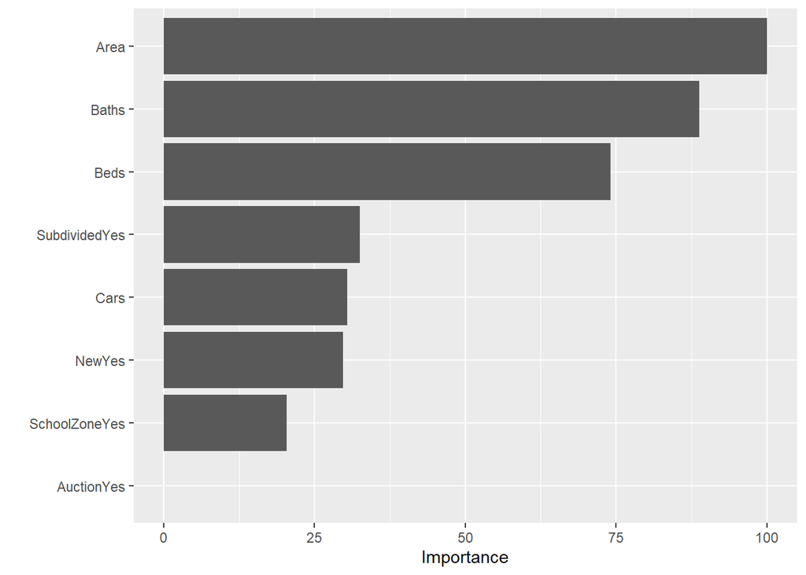

```r
# Plotting variable importance from the algorithm
vip(bag)
```

Unfortunately, there is no easy way of summarizing the bagging algorithm results. The only results that can be read from the output is the summary of resampling results. These suggest a predictive $R^2$ of about 61.8%. We can also extract the variable importance plot that is extracted from the base tree, which indicates that the top three most important variables in real estate price determination are area, the number of bathrooms and the number of bedrooms.

As per usual, the real test is going to be in the algorithm’s predictive performance over the test set. Let us assess this:

```r
# Predicting test data using trained bag
y_bag <- predict(bag, newdata = testData)

# Calculate and compile predictive accuracy metrics
stats_bag <- cbind(csaccuracy(testData[,"Price"],y_bag,mean(trainData[,"Price"])),
                    Banker=banker(testData[,"Price"]-y_bag),
                    REAgent=agent(testData[,"Price"]-y_bag,testData[,"Price"]))

#Gathering predictive accuracy statistics
allstats=rbind(allstats[1:8,],stats_bag)
rownames(allstats)[9]='Bagging(Tree)'
allstats
```

```
##                   RMSE      MAE     MAPE      MASE   Banker   REAgent
## Linear        296.3371 185.7684 13.88486 0.5915656 259.7297  75.43717
## Stepwise      295.6283 186.3040 13.93978 0.5932714 260.2968  77.58615
## Nonlinear     280.5423 175.7471 13.38706 0.5596538 245.3497  80.46086
## RegTree       305.5240 212.4015 16.75901 0.6763770 306.1961 109.88861
## NeuralNet     393.6379 247.6763 18.43003 0.7887069 353.7975 125.99764
## kMeans        357.7008 236.2117 18.42448 0.7521987 348.1406 121.58255
## kMeansReg     285.6843 182.0347 13.63729 0.5796760 253.9720  75.95538
## knn           327.9338 206.0074 15.42880 0.6560154 281.2654  98.40100
## Bagging(Tree) 286.8766 184.7518 14.03469 0.5883283 258.9011  87.47015
```

### Random Forest

```r
# Load randomForest library
library(randomForest)
# Set random seet to make sure results remain static
set.seed(1234)
randFor = randomForest(Price ~ ., data = trainData, importance = TRUE,
                       ntrees = 50, mtry=2)
print(randFor)
```

```
##
## Call:
##  randomForest(formula = Price ~ ., data = trainData, importance = TRUE,      ntrees = 50, mtry = 2)
##                Type of random forest: regression
##                      Number of trees: 500
## No. of variables tried at each split: 2
##
##           Mean of squared residuals: 57155.95
##                     % Var explained: 64.31
```

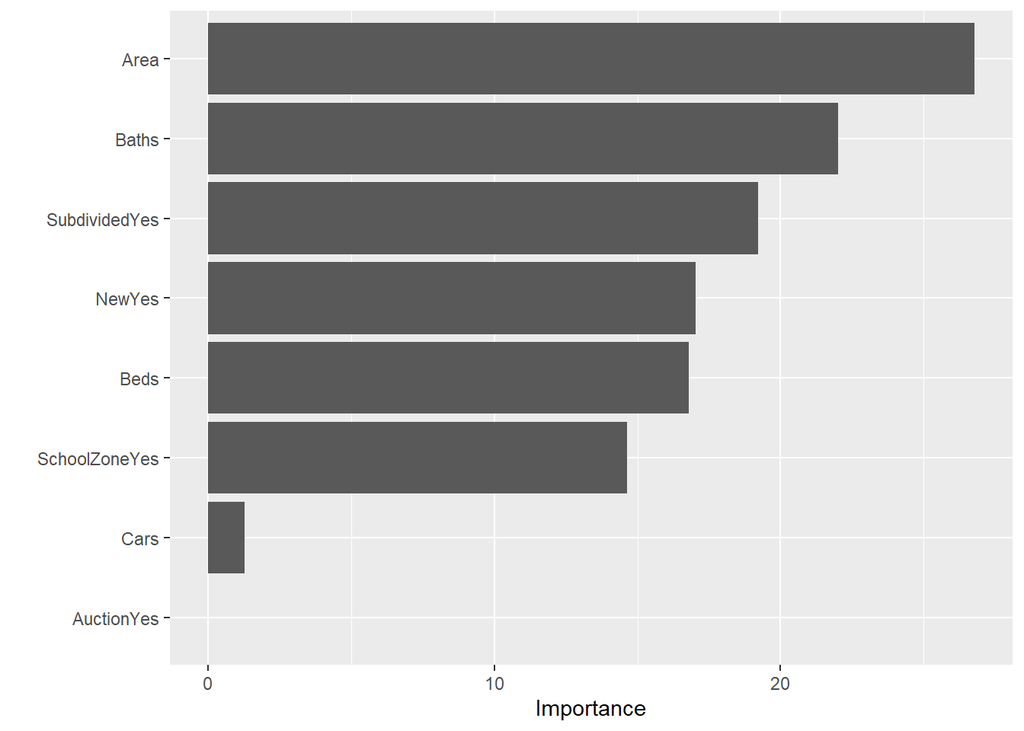

```r
# Plot variable importance
vip(randFor)
```

The random forest variable importance plot indicate that the top three most important variables are area, baths and whether the property was subdivided. The number of bedrooms is ranked fifth here. Let us compute the test set predictive accuracy for comparison:

```r
# Predicting test data using trained forest
y_rf<- predict(randFor, newdata = testData)

# Calculate and compile predictive accuracy metrics
stats_rf <- cbind(csaccuracy(testData[,"Price"],y_rf,mean(trainData[,"Price"])),
                    Banker=banker(testData[,"Price"]-y_rf),
                    REAgent=agent(testData[,"Price"]-y_rf,testData[,"Price"]))

#Gathering predictive accuracy statistics
allstats=rbind(allstats[1:9,],stats_rf)
rownames(allstats)[10]='Random Forest'
allstats
```

```
##                   RMSE      MAE     MAPE      MASE   Banker   REAgent
## Linear        296.3371 185.7684 13.88486 0.5915656 259.7297  75.43717
## Stepwise      295.6283 186.3040 13.93978 0.5932714 260.2968  77.58615
## Nonlinear     280.5423 175.7471 13.38706 0.5596538 245.3497  80.46086
## RegTree       305.5240 212.4015 16.75901 0.6763770 306.1961 109.88861
## NeuralNet     393.6379 247.6763 18.43003 0.7887069 353.7975 125.99764
## kMeans        357.7008 236.2117 18.42448 0.7521987 348.1406 121.58255
## kMeansReg     285.6843 182.0347 13.63729 0.5796760 253.9720  75.95538
## knn           327.9338 206.0074 15.42880 0.6560154 281.2654  98.40100
## Bagging(Tree) 286.8766 184.7518 14.03469 0.5883283 258.9011  87.47015
## Random Forest 289.9173 184.6070 13.89035 0.5878674 265.1386  80.99452
```

The random forest algorithm perform similarly to bagging according to the MAE and MASE, is worse than bagging according to RMSE and the Banker’s loss, but performs better than bagging according to MAPE and the real estate agent’s loss. To discriminate between these two methods, one needs to be clear about the use of predictions and select a method that is consistent with the context specific loss.

### Boosting

Boosting algorithms are designed to improve upon a weak learning base model. For this real estate prices example, we will apply boosting to the linear regression model using the “mboost” library. As discussed in the lecture notes, a key control to boosting algorithms is the learning rate “nu”. The default learning rate set by the library is 0.1. You can experiment with learning rate adjustments. Since the learning rate determines how fast the boosting algorithm make adjustments between iterations, lower values of “nu” means more steps and the algorithm may take longer to converge. For this particular example, I have chosen to use “nu=0.05” as it produces better predictions than the default value.

```r
#Load the mboost library
library(mboost)
#Set random seed and train the boosting algorithm
set.seed(1234)
boost <- glmboost(Price~., data = trainData,
                  control=boost_control(nu=0.05))
summary(boost)
```

```
##
##   Generalized Linear Models Fitted via Gradient Boosting
##
## Call:
## glmboost.formula(formula = Price ~ ., data = trainData, control = boost_control(nu = 0.05))
##
##
##   Squared Error (Regression)
##
## Loss function: (y - f)^2
##
##
## Number of boosting iterations: mstop = 100
## Step size:  0.05
## Offset:  1201.935
##
## Coefficients:
##   (Intercept)          Beds         Baths          Cars          Area
##  -1070.104156     48.703940    141.065756     30.092618      0.745397
## SchoolZoneYes        NewYes
##    121.638575     63.893661
## attr(,"offset")
## [1] 1201.935
##
## Selection frequencies:
##          Area         Baths SchoolZoneYes        NewYes          Cars
##          0.34          0.21          0.18          0.13          0.08
##          Beds
##          0.06
```

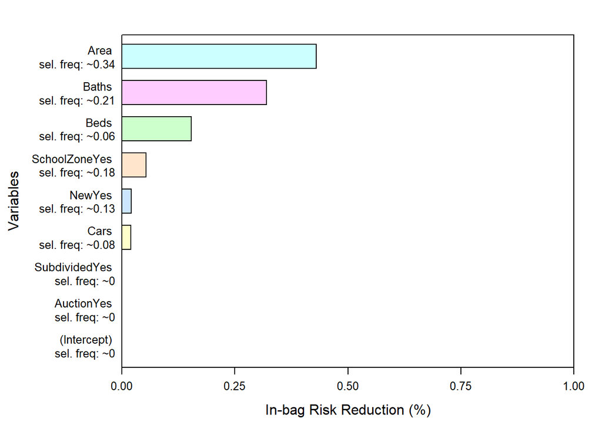

```r
#Variable importance plot - mboost library has its own function
plot(varimp(boost))
```

The summary of the trained algorithm outlines the coefficient of the base model. These coefficients are not to be interpreted as per the usual regression coefficient, but are only to be used as indicative only. We can, however, construct the variable importance plot from the output. The boosting algorithm suggests that the top three most important variables are area, baths and beds, judged by risk reduction percentages.

Since “glmboost()” does component-wise boosting, the variable importance plot also give information about the selection frequency. Variables with higher selection frequency are variables that are included in the prediction more frequently. However, you will notice that just because a variable is selected more often does not necessarily imply that it is more important in reducing the loss. You will see this clearly with the variable “Beds”. Even though its selection frequency is only 6% it is contributes more to the reduction of loss than “SchoolZone”, whose selection frequency is three times higher at 18%.

Predictive accuracy metrices for the test set predictions are computed below.

```r
# Predicting test data using the trained boosting algorithm
y_boost <- predict(boost, newdata = testData)

# Calculate and compile predictive accuracy metrics
stats_boost <- cbind(csaccuracy(testData[,"Price"],y_boost,mean(trainData[,"Price"])),
                    Banker=banker(testData[,"Price"]-y_boost),
                    REAgent=agent(testData[,"Price"]-y_boost,testData[,"Price"]))

#Gathering predictive accuracy statistics
allstats=rbind(allstats[1:10,],stats_boost)
rownames(allstats)[11]='Boosting'
allstats
```

```
##                   RMSE      MAE     MAPE      MASE   Banker   REAgent
## Linear        296.3371 185.7684 13.88486 0.5915656 259.7297  75.43717
## Stepwise      295.6283 186.3040 13.93978 0.5932714 260.2968  77.58615
## Nonlinear     280.5423 175.7471 13.38706 0.5596538 245.3497  80.46086
## RegTree       305.5240 212.4015 16.75901 0.6763770 306.1961 109.88861
## NeuralNet     393.6379 247.6763 18.43003 0.7887069 353.7975 125.99764
## kMeans        357.7008 236.2117 18.42448 0.7521987 348.1406 121.58255
## kMeansReg     285.6843 182.0347 13.63729 0.5796760 253.9720  75.95538
## knn           327.9338 206.0074 15.42880 0.6560154 281.2654  98.40100
## Bagging(Tree) 286.8766 184.7518 14.03469 0.5883283 258.9011  87.47015
## Random Forest 289.9173 184.6070 13.89035 0.5878674 265.1386  80.99452
## Boosting      307.3057 181.5844 13.29081 0.5782422 251.0164  70.21862
```

The boosting algorithm improves upon the linear regression model (top row) on most aspects, with the only exception being the RMSE. Boosting also generates the lowest real estate agent loss, and the second lowest banker loss, among the models considered so far.

### Support Vector Machine Regression

Support vector machine for regression is applied in this section. Since the output variable, Price, is numeric, the svm() function recognizes that this is a regression application. The kernel function used here is linear, although this may not necessarily result in a globally linear relationship between the input and output variables. The linearity applies locally within a certain range, and through the SVM algorithm, generates a much more flexible prediction function. Other options include polynomial, radial and sigmoid kernels. The latter two are not recommended for regression problems for numeric outputs.

```r
# load the svm library
library(e1071)
svmm <- svm(Price~., data=trainData, kernel = "linear")
svmm
```

```
##
## Call:
## svm(formula = Price ~ ., data = trainData, kernel = "linear")
##
##
## Parameters:
##    SVM-Type:  eps-regression
##  SVM-Kernel:  linear
##        cost:  1
##       gamma:  0.125
##     epsilon:  0.1
##
##
## Number of Support Vectors:  228
```

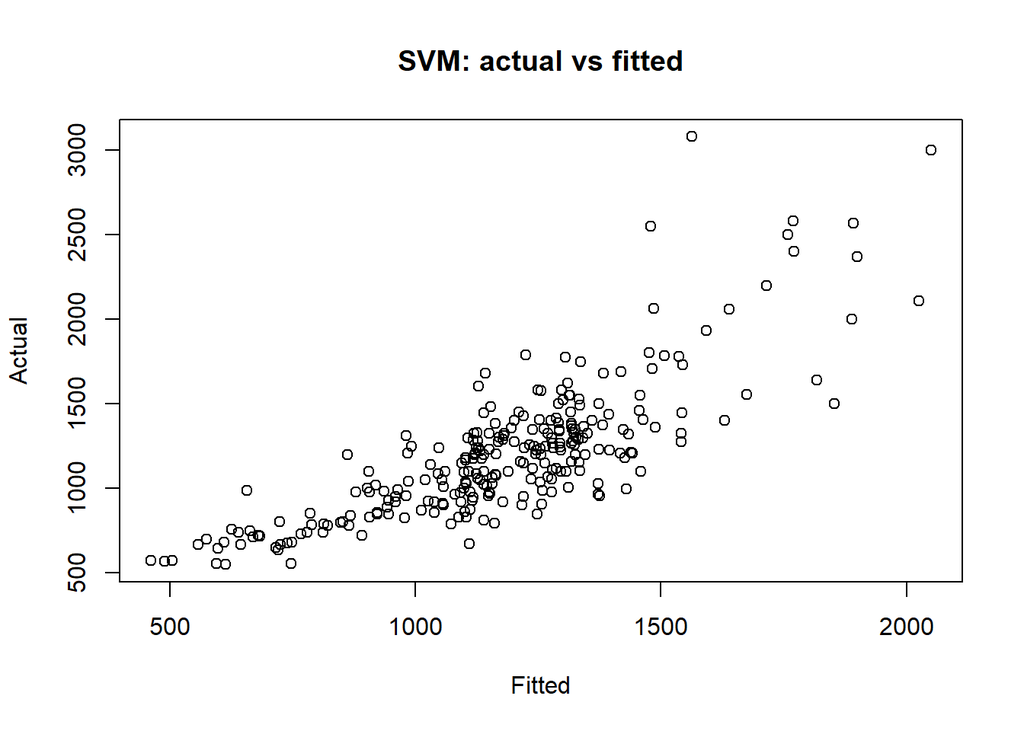

```r
#plotting svm fitted values against actual data
plot(x=svmm$fitted,y=trainData[,"Price"],
     xlab="Fitted", ylab="Actual", main="SVM: actual vs fitted")
```

```r
# Predict the test data using trained svm
y_svmm <- predict(svmm, newdata=testData)

# Calculate and compile predictive accuracy metrics
stats_svm <- cbind(csaccuracy(testData[,"Price"],y_svmm,mean(trainData[,"Price"])),
                    Banker=banker(testData[,"Price"]-y_svmm),
                    REAgent=agent(testData[,"Price"]-y_svmm,testData[,"Price"]))

#Gathering predictive accuracy statistics
allstats=rbind(allstats[1:11,],stats_svm)
rownames(allstats)[12]='SVMReg'
allstats
```

```
##                   RMSE      MAE     MAPE      MASE   Banker   REAgent
## Linear        296.3371 185.7684 13.88486 0.5915656 259.7297  75.43717
## Stepwise      295.6283 186.3040 13.93978 0.5932714 260.2968  77.58615
## Nonlinear     280.5423 175.7471 13.38706 0.5596538 245.3497  80.46086
## RegTree       305.5240 212.4015 16.75901 0.6763770 306.1961 109.88861
## NeuralNet     393.6379 247.6763 18.43003 0.7887069 353.7975 125.99764
## kMeans        357.7008 236.2117 18.42448 0.7521987 348.1406 121.58255
## kMeansReg     285.6843 182.0347 13.63729 0.5796760 253.9720  75.95538
## knn           327.9338 206.0074 15.42880 0.6560154 281.2654  98.40100
## Bagging(Tree) 286.8766 184.7518 14.03469 0.5883283 258.9011  87.47015
## Random Forest 289.9173 184.6070 13.89035 0.5878674 265.1386  80.99452
## Boosting      307.3057 181.5844 13.29081 0.5782422 251.0164  70.21862
## SVMReg        303.6053 177.0323 12.81974 0.5637463 230.6665  68.92545
```

The only way to assess the performance of SVM is via predictive assessment. From the test set accuracy metrics, it can be observed that the SVM algorithm is a strong contender in predicting our real estate prices, with it being the best performer in the MAPE and in both of the context specific losses. Even though it is not the top performing model according to the other statistical metrics, it is not significantly lower than the top performing model.

```r
#Save the workspace
save.image('REPriceSession4.RData')
```

### A final note

**It is important to recognize here that any conclusions made about model performance is very much context specific. When applied to other predictive problems, your conclusions may vary greatly depending on the features of the data and the context specific loss.**